# RNA-Seq Differential Expression

Martin Morgan (martin.morgan@roswellpark.org) Roswell Park Cancer Institute, Buffalo, NY 5 - 9 October, 2015

# Contents

The material in this course requires R version 3.2 and Bioconductor version 3.2

```r
stopifnot(
    getRversion() >= '3.2' && getRversion() < '3.3',
    BiocInstaller::biocVersion() == "3.2"
)
```

# 1 Background

For Review:

- Overall Workflow
- Specifying Experimental Design in *R*

This lab is derived from: [RNA-Seq workflow: gene-level exploratory analysis and differential expression](http://bioconductor.org/help/workflows/rnaseqGene/), by Michael Love, Simon Anders, Wolfgang Huber; modified by Martin Morgan, October 2015.

This lab will walk you through an end-to-end RNA-Seq differential expression workflow, using DESeq2 along with other *Bioconductor* packages. The complete work flow starts from the FASTQ files, but we will start after reads have been aligned to a reference genome and reads overlapping known genes have been counted. We will perform exploratory data analysis (EDA), differential gene expression analysis with DESeq2, and visually explore the results.

A number of other *Bioconductor* packages are important in statistical inference of differential expression at the gene level, including Rsubread, edgeR, limma, BaySeq, and others.

# 2 Experimental data

The data used in this workflow is an RNA-Seq experiment of airway smooth muscle cells treated with dexamethasone, a synthetic glucocorticoid steroid with anti-inflammatory effects. Glucocorticoids are used, for example, in asthma patients to prevent or reduce inflammation of the airways. In the experiment, four primary human airway smooth muscle cell lines were treated with 1 micromolar dexamethasone for 18 hours. For each of the four cell lines, we have a treated and an untreated sample. The reference for the experiment is:

Himes BE, Jiang X, Wagner P, Hu R, Wang Q, Klanderman B, Whitaker RM, Duan Q, Lasky-Su J, Nikolos C, Jester W, Johnson M, Panettieri R Jr, Tantisira KG, Weiss ST, Lu Q. “RNA-Seq Transcriptome Profiling Identifies CRISPLD2 as a Glucocorticoid Responsive Gene that Modulates Cytokine Function in Airway Smooth Muscle Cells.” PLoS One. 2014 Jun 13;9(6):e99625. PMID: 24926665. GEO: GSE52778.

# 3 Preparing count matrices

As input, DESeq2 package expects count data as obtained, e.g., from RNA-Seq or another high-throughput sequencing experiment, in the form of a matrix of integer values. The value in the *i*-th row and the *j*-th column of the matrix tells how many reads have been mapped to gene *i* in sample *j*. Analogously, for other types of assays, the rows of the matrix might correspond e.g., to binding regions (with ChIP-Seq) or peptide sequences (with quantitative mass spectrometry).

The count values must be raw counts of sequencing reads. This is important for DESeq2’s statistical model to hold, as only the actual counts allow assessing the measurement precision correctly. Hence, please do not supply other quantities, such as (rounded) normalized counts, or counts of covered base pairs – this will only lead to nonsensical results.

We will discuss how to summarize data from BAM files to a count table later in ther course. Here we’ll ‘jump right in’ and start with a prepared `SummarizedExperiment`.

# 4 Starting from `SummarizedExperiment`

```r
library(airway)
data("airway")
se <- airway
```

The information in a `SummarizedExperiment` object can be accessed with accessor functions. For example, to see the actual data, i.e., here, the read counts, we use the `assay()` function. (The `head()` function restricts the output to the first few lines.)

```r
head(assay(se))
```

```
##                 SRR1039508 SRR1039509 SRR1039512 SRR1039513 SRR1039516 SRR1039517 SRR1039520
## ENSG00000000003        679        448        873        408       1138       1047        770
## ENSG00000000005          0          0          0          0          0          0          0
## ENSG00000000419        467        515        621        365        587        799        417
## ENSG00000000457        260        211        263        164        245        331        233
## ENSG00000000460         60         55         40         35         78         63         76
## ENSG00000000938          0          0          2          0          1          0          0
##                 SRR1039521
## ENSG00000000003        572
## ENSG00000000005          0
## ENSG00000000419        508
## ENSG00000000457        229
## ENSG00000000460         60
## ENSG00000000938          0
```

In this count matrix, each row represents an Ensembl gene, each column a sequenced RNA library, and the values give the raw numbers of sequencing reads that were mapped to the respective gene in each library. We also have metadata on each of the samples (the columns of the count matrix). If you’ve counted reads with some other software, you need to check at this step that the columns of the count matrix correspond to the rows of the column metadata.

We can quickly check the millions of fragments which uniquely aligned to the genes.

```r
colSums(assay(se))
```

```
## SRR1039508 SRR1039509 SRR1039512 SRR1039513 SRR1039516 SRR1039517 SRR1039520 SRR1039521
##   20637971   18809481   25348649   15163415   24448408   30818215   19126151   21164133
```

Supposing we have constructed a `SummarizedExperiment` using one of the methods described in the previous section, we now need to make sure that the object contains all the necessary information about the samples, i.e., a table with metadata on the count matrix’s columns stored in the `colData` slot:

```r
colData(se)
```

```
## DataFrame with 8 rows and 9 columns
##            SampleName     cell      dex    albut        Run avgLength Experiment    Sample
##              <factor> <factor> <factor> <factor>   <factor> <integer>   <factor>  <factor>
## SRR1039508 GSM1275862   N61311    untrt    untrt SRR1039508       126  SRX384345 SRS508568
## SRR1039509 GSM1275863   N61311      trt    untrt SRR1039509       126  SRX384346 SRS508567
## SRR1039512 GSM1275866  N052611    untrt    untrt SRR1039512       126  SRX384349 SRS508571
## SRR1039513 GSM1275867  N052611      trt    untrt SRR1039513        87  SRX384350 SRS508572
## SRR1039516 GSM1275870  N080611    untrt    untrt SRR1039516       120  SRX384353 SRS508575
## SRR1039517 GSM1275871  N080611      trt    untrt SRR1039517       126  SRX384354 SRS508576
## SRR1039520 GSM1275874  N061011    untrt    untrt SRR1039520       101  SRX384357 SRS508579
## SRR1039521 GSM1275875  N061011      trt    untrt SRR1039521        98  SRX384358 SRS508580
##               BioSample
##                <factor>
## SRR1039508 SAMN02422669
## SRR1039509 SAMN02422675
## SRR1039512 SAMN02422678
## SRR1039513 SAMN02422670
## SRR1039516 SAMN02422682
## SRR1039517 SAMN02422673
## SRR1039520 SAMN02422683
## SRR1039521 SAMN02422677
```

Here we see that this object already contains an informative `colData` slot – because we have already prepared it for you, as described in the airway vignette. However, when you work with your own data, you will have to add the pertinent sample / phenotypic information for the experiment at this stage. We highly recommend keeping this information in a comma-separated value (CSV) or tab-separated value (TSV) file, which can be exported from an Excel spreadsheet, and the assign this to the `colData` slot, making sure that the rows correspond to the columns of the `SummarizedExperiment`. We made sure of this correspondence by specifying the BAM files using a column of the sample table.

# 5 From `SummarizedExperiment` to `DESeqDataSet`

We will use the DESeq2 package for assessing differential expression. The package uses an extended version of the `SummarizedExperiment` calass, called `DESeqDataSet`. It’s easy to go from a `SummarizedExperiment` to `DESeqDataSet`:

```r
library("DESeq2")
dds <- DESeqDataSet(se, design = ~ cell + dex)
```

# 6 Visually exploring the dataset

### 6.0.1 The rlog transformation

Many common statistical methods for exploratory analysis of multidimensional data, especially methods for clustering and ordination (e.g., principal-component analysis and the like), work best for (at least approximately) homoskedastic data; this means that the variance of an observed quantity (here, the expression strength of a gene) does not depend on the mean. In RNA-Seq data, however, variance grows with the mean. For example, if one performs PCA (principal components analysis) directly on a matrix of normalized read counts, the result typically depends only on the few most strongly expressed genes because they show the largest absolute differences between samples. A simple and often used strategy to avoid this is to take the logarithm of the normalized count values plus a small pseudocount; however, now the genes with low counts tend to dominate the results because, due to the strong Poisson noise inherent to small count values, they show the strongest relative differences between samples.

As a solution, DESeq2 offers the *regularized-logarithm transformation*, or `rlog()` for short. For genes with high counts, the rlog transformation differs not much from an ordinary log2 transformation. For genes with lower counts, however, the values are shrunken towards the genes’ averages across all samples. Using an empirical Bayesian prior on inter-sample differences in the form of a *ridge penalty*, this is done such that the rlog-transformed data are approximately homoskedastic. See the help for `?rlog` for more information and options. Another transformation, the *variance stabilizing transformation* (`vsn()`), is discussed alongside the `rlog()` in the DESeq2 vignette.

**Note:** the rlog transformation is provided for applications *other* than differential testing. For differential testing we recommend the `DESeq()` function applied to raw counts, as described later in this workflow, which also takes into account the dependence of the variance of counts on the mean value during the dispersion estimation step.

The function `rlog()` returns a `SummarizedExperiment` object which contains the rlog-transformed values in its `assay()` slot:

```r
rld <- rlog(dds)
head(assay(rld))
```

```
##                 SRR1039508 SRR1039509 SRR1039512 SRR1039513 SRR1039516 SRR1039517 SRR1039520
## ENSG00000000003   9.399151   9.142478   9.501695   9.320796   9.757212   9.512183   9.617378
## ENSG00000000005   0.000000   0.000000   0.000000   0.000000   0.000000   0.000000   0.000000
## ENSG00000000419   8.901283   9.113976   9.032567   9.063925   8.981930   9.108531   8.894830
## ENSG00000000457   7.949897   7.882371   7.834273   7.916459   7.773819   7.886645   7.946411
## ENSG00000000460   5.849521   5.882363   5.486937   5.770334   5.940407   5.663847   6.107733
## ENSG00000000938  -1.638084  -1.637483  -1.558248  -1.636072  -1.597606  -1.639362  -1.637608
##                 SRR1039521
## ENSG00000000003   9.315309
## ENSG00000000005   0.000000
## ENSG00000000419   9.052303
## ENSG00000000457   7.908338
## ENSG00000000460   5.907824
## ENSG00000000938  -1.637724
```

To show the effect of the transformation, we plot the first sample against the second, first simply using the `log2()` function (after adding 1, to avoid taking the log of zero), and then using the rlog-transformed values. For the `log2()` method, we need estimate size factors to account for sequencing depth (this is done automatically for the `rlog()` method).

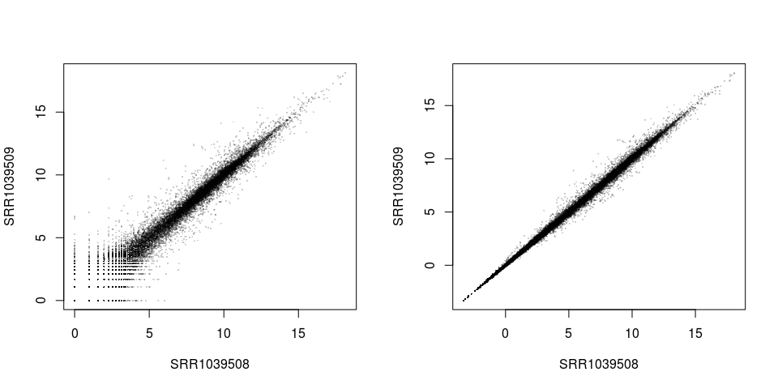

```r
opar <- par( mfrow = c( 1, 2 ) )
dds <- estimateSizeFactors(dds)
plot( log2( 1 + counts(dds, normalized=TRUE)[ , 1:2] ),
     col=rgb(0,0,0,.2), pch=16, cex=0.3 )
plot( assay(rld)[ , 1:2],
     col=rgb(0,0,0,.2), pch=16, cex=0.3 )
```

```r
par(opar)
```

Note that, in order to make it easier to see where several points are plotted on top of each other, we set the plotting color to a semi-transparent black and changed the points to solid circles (`pch=16`) with reduced size (`cex=0.3`).

We can see how genes with low counts seem to be excessively variable on the ordinary logarithmic scale, while the rlog transform compresses differences for genes for which the data cannot provide good information anyway.

### 6.0.2 Sample distances

A useful first step in an RNA-Seq analysis is often to assess overall similarity between samples: Which samples are similar to each other, which are different? Does this fit to the expectation from the experiment’s design?

We use the R function `dist()` to calculate the Euclidean distance between samples. To avoid that the distance measure is dominated by a few highly variable genes, and have a roughly equal contribution from all genes, we use it on the rlog-transformed data:

```r
sampleDists <- dist( t( assay(rld) ) )
sampleDists
```

```
##            SRR1039508 SRR1039509 SRR1039512 SRR1039513 SRR1039516 SRR1039517 SRR1039520
## SRR1039509   40.89060
## SRR1039512   37.35231   50.07638
## SRR1039513   55.74569   41.49280   43.61052
## SRR1039516   41.98797   53.58929   40.99513   57.10447
## SRR1039517   57.69438   47.59326   53.52310   46.13742   42.10583
## SRR1039520   37.06633   51.80994   34.86653   52.54968   43.21786   57.13688
## SRR1039521   56.04254   41.46514   51.90045   34.82975   58.40428   47.90244   44.78171
```

Note the use of the function `t()` to transpose the data matrix. We need this because `dist()` calculates distances between data *rows* and our samples constitute the columns.

We visualize the distances in a heatmap, using the function `heatmap.2()` from the gplots package.

```r
library("gplots")
library("RColorBrewer")
```

We have to provide a hierarchical clustering `hc` to the `heatmap.2()` function based on the sample distances, or else the `heatmap.2()` function would calculate a clustering based on the distances between the rows/columns of the distance matrix.

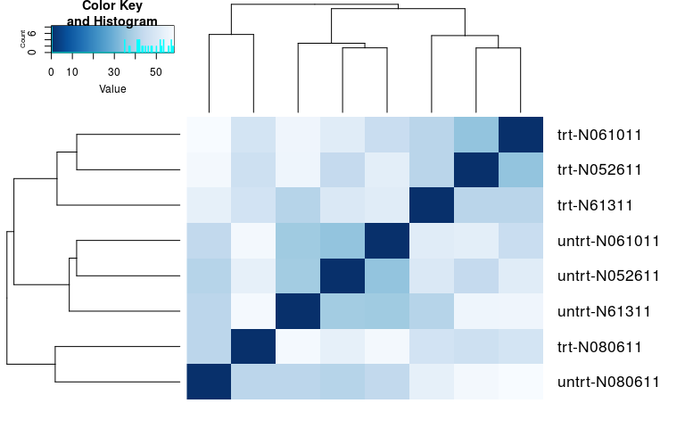

```r
sampleDistMatrix <- as.matrix( sampleDists )
rownames(sampleDistMatrix) <- paste( rld$dex, rld$cell, sep="-" )
colors <- colorRampPalette( rev(brewer.pal(9, "Blues")) )(255)
hc <- hclust(sampleDists)
heatmap.2( sampleDistMatrix, Rowv=as.dendrogram(hc),
          symm=TRUE, trace="none", col=colors,
          margins=c(2,10), labCol=FALSE )
```

Note that we have changed the row names of the distance matrix to contain treatment type and patient number instead of sample ID, so that we have all this information in view when looking at the heatmap.

### 6.0.3 PCA plot

Another way to visualize sample-to-sample distances is a principal-components analysis (PCA). In this ordination method, the data points (i.e., here, the samples) are projected onto the 2D plane such that they spread out in the two directions which explain most of the differences in the data. The x-axis is the direction (or principal component) which separates the data points the most. The amount of the total variance which is contained in the direction is printed in the axis label.

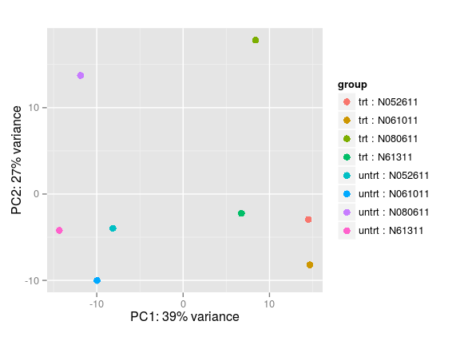

```r
plotPCA(rld, intgroup = c("dex", "cell"))
```

Here, we have used the function `plotPCA()` which comes with DESeq2. The two terms specified by `intgroup` are the interesting groups for labelling the samples; they tell the function to use them to choose colors. We can also build the PCA plot from scratch using *[ggplot2](http://cran.fhcrc.org/web/packages/ggplot2/index.html)*. This is done by asking the `plotPCA()` function to return the data used for plotting rather than building the plot. See the ggplot2 [documentation](http://docs.ggplot2.org/current/) for more details.

```r
(data <- plotPCA(rld, intgroup = c( "dex", "cell"), returnData=TRUE))
```

```
##                   PC1        PC2           group   dex    cell       name
## SRR1039508 -14.331359  -4.208796  untrt : N61311 untrt  N61311 SRR1039508
## SRR1039509   6.754169  -2.245244    trt : N61311   trt  N61311 SRR1039509
## SRR1039512  -8.130393  -3.952904 untrt : N052611 untrt N052611 SRR1039512
## SRR1039513  14.505648  -2.941862   trt : N052611   trt N052611 SRR1039513
## SRR1039516 -11.891410  13.735002 untrt : N080611 untrt N080611 SRR1039516
## SRR1039517   8.373975  17.823844   trt : N080611   trt N080611 SRR1039517
## SRR1039520  -9.965898 -10.014674 untrt : N061011 untrt N061011 SRR1039520
## SRR1039521  14.685269  -8.195366   trt : N061011   trt N061011 SRR1039521
```

```r
percentVar <- round(100 * attr(data, "percentVar"))
```

We can then use this data to build up the plot, specifying that the color of the points should reflect dexamethasone treatment and the shape should reflect the cell line.

```r
library("ggplot2")
```

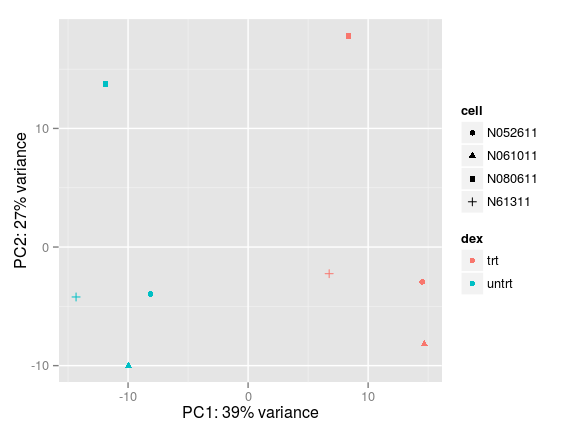

```r
qplot(PC1, PC2, color=dex, shape=cell, data=data) +
  xlab(paste0("PC1: ", percentVar[1], "% variance")) +
  ylab(paste0("PC2: ", percentVar[2], "% variance"))
```

From both visualizations, we see that the differences between cells are considerable, though not stronger than the differences due to treatment with dexamethasone. This shows why it will be important to account for this in differential testing by using a paired design (“paired”, because each dex treated sample is paired with one untreated sample from the *same* cell line). We are already set up for this by using the design formula `~ cell + dex` when setting up the data object in the beginning.

# 7 Differential expression analysis

It will be convenient to make sure that `untrt` is the first level in the `dex` factor, so that the default log2 fold changes are calculated as treated over untreated (by default R will chose the first alphabetical level, remember: computers don’t know what to do unless you tell them). The function `relevel()` achieves this:

```r
dds$dex <- relevel(dds$dex, "untrt")
```

In addition, if you have at any point subset the columns of the `DESeqDataSet` you should similarly call `droplevels()` on the factors if the subsetting has resulted in some levels having 0 samples.

## 7.1 Running the pipeline

Finally, we are ready to run the differential expression pipeline. With the data object prepared, the DESeq2 analysis can now be run with a single call to the function `DESeq()`:

```r
dds <- DESeq(dds)
```

This function will print out a message for the various steps it performs. These are described in more detail in the manual page `?DESeq`. Briefly these are: the estimation of size factors (which control for differences in the library size of the sequencing experiments), the estimation of dispersion for each gene, and fitting a generalized linear model.

A `DESeqDataSet` is returned which contains all the fitted information within it, and the following section describes how to extract out results tables of interest from this object.

## 7.2 Building the results table

Calling `results()` without any arguments will extract the estimated log2 fold changes and *p* values for the last variable in the design formula. If there are more than 2 levels for this variable, `results()` will extract the results table for a comparison of the last level over the first level.

```r
(res <- results(dds))
```

```
## log2 fold change (MAP): dex trt vs untrt
## Wald test p-value: dex trt vs untrt
## DataFrame with 64102 rows and 6 columns
##                  baseMean log2FoldChange      lfcSE       stat       pvalue        padj
##                 <numeric>      <numeric>  <numeric>  <numeric>    <numeric>   <numeric>
## ENSG00000000003 708.60217    -0.37424998 0.09873107 -3.7906000 0.0001502838 0.001251416
## ENSG00000000005   0.00000             NA         NA         NA           NA          NA
## ENSG00000000419 520.29790     0.20215551 0.10929899  1.8495642 0.0643763851 0.192284345
## ENSG00000000457 237.16304     0.03624826 0.13684258  0.2648902 0.7910940556 0.910776144
## ENSG00000000460  57.93263    -0.08523371 0.24654402 -0.3457140 0.7295576905 0.878646940
## ...                   ...            ...        ...        ...          ...         ...
## LRG_94                  0             NA         NA         NA           NA          NA
## LRG_96                  0             NA         NA         NA           NA          NA
## LRG_97                  0             NA         NA         NA           NA          NA
## LRG_98                  0             NA         NA         NA           NA          NA
## LRG_99                  0             NA         NA         NA           NA          NA
```

As `res` is a `DataFrame` object, it carries metadata with information on the meaning of the columns:

```r
mcols(res, use.names=TRUE)
```

```
## DataFrame with 6 rows and 2 columns
##                        type                               description
##                 <character>                               <character>
## baseMean       intermediate mean of normalized counts for all samples
## log2FoldChange      results  log2 fold change (MAP): dex trt vs untrt
## lfcSE               results          standard error: dex trt vs untrt
## stat                results          Wald statistic: dex trt vs untrt
## pvalue              results       Wald test p-value: dex trt vs untrt
## padj                results                      BH adjusted p-values
```

The first column, `baseMean`, is a just the average of the normalized count values, dividing by size factors, taken over all samples. The remaining four columns refer to a specific contrast, namely the comparison of the `trt` level over the `untrt` level for the factor variable `dex`. See the help page for `results()` (by typing `?results`) for information on how to obtain other contrasts.

The column `log2FoldChange` is the effect size estimate. It tells us how much the gene’s expression seems to have changed due to treatment with dexamethasone in comparison to untreated samples. This value is reported on a logarithmic scale to base 2: for example, a log2 fold change of 1.5 means that the gene’s expression is increased by a multiplicative factor of $2^{1.5} \approx 2.82$.

Of course, this estimate has an uncertainty associated with it, which is available in the column `lfcSE`, the standard error estimate for the log2 fold change estimate. We can also express the uncertainty of a particular effect size estimate as the result of a statistical test. The purpose of a test for differential expression is to test whether the data provides sufficient evidence to conclude that this value is really different from zero. DESeq2 performs for each gene a *hypothesis test* to see whether evidence is sufficient to decide against the *null hypothesis* that there is no effect of the treatment on the gene and that the observed difference between treatment and control was merely caused by experimental variability (i.e., the type of variability that you can just as well expect between different samples in the same treatment group). As usual in statistics, the result of this test is reported as a *p* value, and it is found in the column `pvalue`. (Remember that a *p* value indicates the probability that a fold change as strong as the observed one, or even stronger, would be seen under the situation described by the null hypothesis.)

We can also summarize the results with the following line of code, which reports some additional information.

```r
summary(res)
```

```
##
## out of 33469 with nonzero total read count
## adjusted p-value < 0.1
## LFC > 0 (up)     : 2641, 7.9%
## LFC < 0 (down)   : 2242, 6.7%
## outliers [1]     : 0, 0%
## low counts [2]   : 15441, 46%
## (mean count < 5)
## [1] see 'cooksCutoff' argument of ?results
## [2] see 'independentFiltering' argument of ?results
```

Note that there are many genes with differential expression due to dexamethasone treatment at the FDR level of 10%. This makes sense, as the smooth muscle cells of the airway are known to react to glucocorticoid steroids. However, there are two ways to be more strict about which set of genes are considered significant:

- lower the false discovery rate threshold (the threshold on `padj` in the results table)
- raise the log2 fold change threshold from 0 using the `lfcThreshold` argument of `results()`. See the DESeq2 vignette for a demonstration of the use of this argument.

Sometimes a subset of the *p* values in `res` will be `NA` (“not available”). This is `DESeq()`’s way of reporting that all counts for this gene were zero, and hence not test was applied. In addition, *p* values can be assigned `NA` if the gene was excluded from analysis because it contained an extreme count outlier. For more information, see the outlier detection section of the vignette.

## 7.3 Other comparisons

In general, the results for a comparison of any two levels of a variable can be extracted using the `contrast` argument to `results()`. The user should specify three values: the name of the variable, the name of the level in the numerator, and the name of the level in the denominator. Here we extract results for the log2 of the fold change of one cell line over another:

```r
results(dds, contrast=c("cell", "N061011", "N61311"))
```

```
## log2 fold change (MAP): cell N061011 vs N61311
## Wald test p-value: cell N061011 vs N61311
## DataFrame with 64102 rows and 6 columns
##                  baseMean log2FoldChange     lfcSE        stat     pvalue      padj
##                 <numeric>      <numeric> <numeric>   <numeric>  <numeric> <numeric>
## ENSG00000000003 708.60217     0.29055775 0.1360076  2.13633388 0.03265221 0.2115083
## ENSG00000000005   0.00000             NA        NA          NA         NA        NA
## ENSG00000000419 520.29790    -0.05069642 0.1491735 -0.33984871 0.73397047 0.9339283
## ENSG00000000457 237.16304     0.01474463 0.1816382  0.08117584 0.93530211 0.9885943
## ENSG00000000460  57.93263     0.20247610 0.2807312  0.72124547 0.47075850 0.8333258
## ...                   ...            ...       ...         ...        ...       ...
## LRG_94                  0             NA        NA          NA         NA        NA
## LRG_96                  0             NA        NA          NA         NA        NA
## LRG_97                  0             NA        NA          NA         NA        NA
## LRG_98                  0             NA        NA          NA         NA        NA
## LRG_99                  0             NA        NA          NA         NA        NA
```

If results for an interaction term are desired, the `name` argument of `results()` should be used. Please see the help for the `results()` function for more details.

## 7.4 Multiple testing

Novices in high-throughput biology often assume that thresholding these *p* values at a low value, say 0.05, as is often done in other settings, would be appropriate – but it is not. We briefly explain why:

There are 5722 genes with a *p* value below 0.05 among the 33469 genes, for which the test succeeded in reporting a *p* value:

```r
sum(res$pvalue < 0.05, na.rm=TRUE)
```

```
## [1] 5722
```

```r
sum(!is.na(res$pvalue))
```

```
## [1] 33469
```

Now, assume for a moment that the null hypothesis is true for all genes, i.e., no gene is affected by the treatment with dexamethasone. Then, by the definition of *p* value, we expect up to 5% of the genes to have a *p* value below 0.05. This amounts to 1673 genes. If we just considered the list of genes with a *p* value below 0.05 as differentially expressed, this list should therefore be expected to contain up to 1673 / 5722 = 29% false positives.

DESeq2 uses the Benjamini-Hochberg (BH) adjustment as described in the base R *p.adjust* function; in brief, this method calculates for each gene an adjusted *p* value which answers the following question: if one called significant all genes with a *p* value less than or equal to this gene’s *p* value threshold, what would be the fraction of false positives (the *false discovery rate*, FDR) among them (in the sense of the calculation outlined above)? These values, called the BH-adjusted *p* values, are given in the column `padj` of the `res` object.

Hence, if we consider a fraction of 10% false positives acceptable, we can consider all genes with an adjusted *p* value below $10% = 0.1$ as significant. How many such genes are there?

```r
sum(res$padj < 0.1, na.rm=TRUE)
```

```
## [1] 4883
```

We subset the results table to these genes and then sort it by the log2 fold change estimate to get the significant genes with the strongest down-regulation.

```r
resSig <- subset(res, padj < 0.1)
head(resSig[ order( resSig$log2FoldChange ), ])
```

```
## log2 fold change (MAP): dex trt vs untrt
## Wald test p-value: dex trt vs untrt
## DataFrame with 6 rows and 6 columns
##                  baseMean log2FoldChange     lfcSE       stat       pvalue         padj
##                 <numeric>      <numeric> <numeric>  <numeric>    <numeric>    <numeric>
## ENSG00000162692 508.17023      -3.453076 0.1764098 -19.574173 2.567708e-85 3.560819e-82
## ENSG00000146006  46.80760      -2.858867 0.3369900  -8.483538 2.184477e-17 1.096985e-15
## ENSG00000105989 333.21469      -2.851447 0.1754994 -16.247620 2.322038e-59 1.231226e-56
## ENSG00000214814 243.27698      -2.760339 0.2225604 -12.402652 2.528167e-35 4.220166e-33
## ENSG00000267339  26.23357      -2.746830 0.3515707  -7.813022 5.583283e-15 2.231828e-13
## ENSG00000013293 244.49733      -2.646722 0.1981697 -13.355834 1.095240e-40 2.295928e-38
```

…and with the strongest upregulation. The `order()` function gives the indices in increasing order, so a simple way to ask for decreasing order is to add a `-` sign. Alternatively, you can use the argument `decreasing=TRUE`.

```r
head(resSig[ order( -resSig$log2FoldChange ), ])
```

```
## log2 fold change (MAP): dex trt vs untrt
## Wald test p-value: dex trt vs untrt
## DataFrame with 6 rows and 6 columns
##                  baseMean log2FoldChange     lfcSE      stat        pvalue          padj
##                 <numeric>      <numeric> <numeric> <numeric>     <numeric>     <numeric>
## ENSG00000179593  67.24305       4.884730 0.3312025  14.74847  3.147214e-49  1.031600e-46
## ENSG00000109906 385.07103       4.865889 0.3324560  14.63619  1.650703e-48  5.130840e-46
## ENSG00000152583 997.43977       4.316100 0.1724127  25.03354 2.637881e-138 4.755573e-134
## ENSG00000250978  56.31819       4.093661 0.3291519  12.43699  1.645805e-35  2.799110e-33
## ENSG00000163884 561.10717       4.079128 0.2103817  19.38917  9.525995e-84  1.073342e-80
## ENSG00000168309 159.52692       3.992788 0.2549099  15.66353  2.685734e-55  1.241498e-52
```

# 8 Diagnostic plots

A quick way to visualize the counts for a particular gene is to use the `plotCounts()` function, which takes as arguments the `DESeqDataSet`, a gene name, and the group over which to plot the counts.

```r
topGene <- rownames(res)[which.min(res$padj)]
data <- plotCounts(dds, gene=topGene, intgroup=c("dex"), returnData=TRUE)
```

We can also make more customizable plots using the `ggplot()` function from the ggplot2 package:

```
## stat_bindot: binwidth defaulted to range/30. Use 'binwidth = x' to adjust this.
```

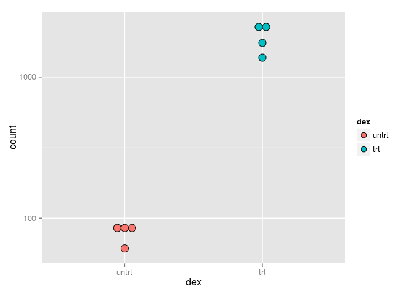

```r
ggplot(data, aes(x=dex, y=count, fill=dex)) +
  scale_y_log10() +
  geom_dotplot(binaxis="y", stackdir="center")
```

An “MA-plot” provides a useful overview for an experiment with a two-group comparison. The log2 fold change for a particular comparison is plotted on the y-axis and the average of the counts normalized by size factor is shown on the x-axis (“M” for minus, because a log ratio is equal to log minus log, and “A” for average).

```r
plotMA(res, ylim=c(-5,5))
```

[output not shown]

Each gene is represented with a dot. Genes with an adjusted $p$ value below a threshold (here 0.1, the default) are shown in red. The DESeq2 package incorporates a prior on log2 fold changes, resulting in moderated log2 fold changes from genes with low counts and highly variable counts, as can be seen by the narrowing of spread of points on the left side of the plot. This plot demonstrates that only genes with a large average normalized count contain sufficient information to yield a significant call.

We can label individual points on the MA plot as well. Here we use the `with()` R function to plot a circle and text for a selected row of the results object. Within the `with()` function, only the `baseMean` and `log2FoldChange` values for the selected rows of `res` are used.

```r
plotMA(res, ylim=c(-5,5))
with(res[topGene, ], {
  points(baseMean, log2FoldChange, col="dodgerblue", cex=2, lwd=2)
  text(baseMean, log2FoldChange, topGene, pos=2, col="dodgerblue")
})
```

[output not shown]

Whether a gene is called significant depends not only on its LFC but also on its within-group variability, which DESeq2 quantifies as the *dispersion*. For strongly expressed genes, the dispersion can be understood as a squared coefficient of variation: a dispersion value of 0.01 means that the gene’s expression tends to differ by typically $\sqrt{0.01} = 10\%$ between samples of the same treatment group. For weak genes, the Poisson noise is an additional source of noise.

The function `plotDispEsts()` visualizes DESeq2’s dispersion estimates:

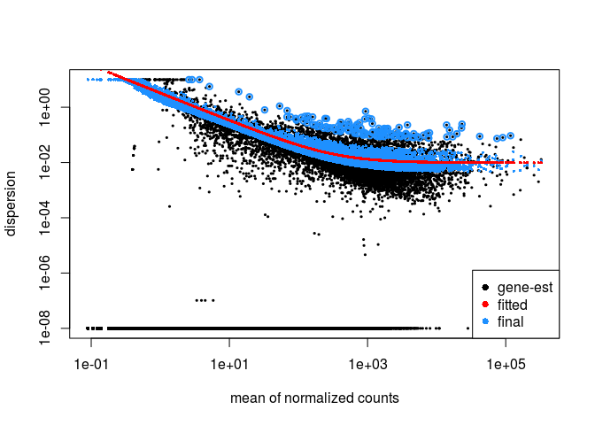

```r
plotDispEsts(dds)
```

The black points are the dispersion estimates for each gene as obtained by considering the information from each gene separately. Unless one has many samples, these values fluctuate strongly around their true values. Therefore, we fit the red trend line, which shows the dispersions’ dependence on the mean, and then shrink each gene’s estimate towards the red line to obtain the final estimates (blue points) that are then used in the hypothesis test. The blue circles above the main “cloud” of points are genes which have high gene-wise dispersion estimates which are labelled as dispersion outliers. These estimates are therefore not shrunk toward the fitted trend line.

Another useful diagnostic plot is the histogram of the *p* values.

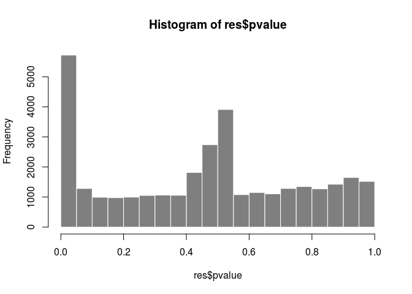

```r
hist(res$pvalue, breaks=20, col="grey50", border="white")
```

This plot becomes a bit smoother by excluding genes with very small counts:

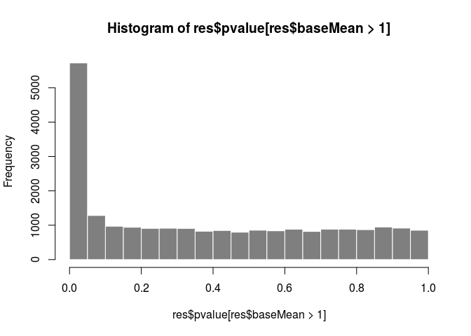

```r
hist(res$pvalue[res$baseMean > 1], breaks=20, col="grey50", border="white")
```

# 9 Gene clustering

In the sample distance heatmap made previously, the dendrogram at the side shows us a hierarchical clustering of the samples. Such a clustering can also be performed for the genes. Since the clustering is only relevant for genes that actually carry signal, one usually carries it out only for a subset of most highly variable genes. Here, for demonstration, let us select the 35 genes with the highest variance across samples. We will work with the `rlog()` transformed counts:

```r
library("genefilter")
topVarGenes <- head(order(-rowVars(assay(rld))),35)
```

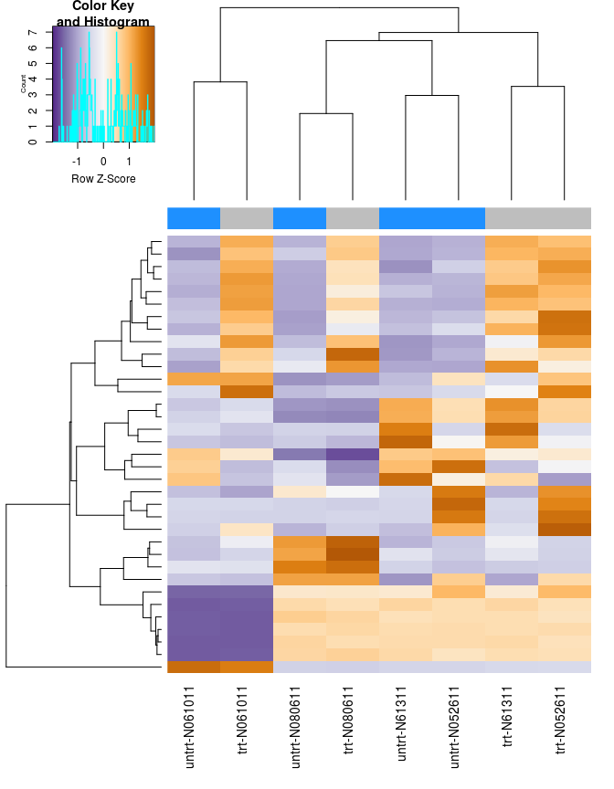

```r
colors <- colorRampPalette( rev(brewer.pal(9, "PuOr")) )(255)
sidecols <- c("grey","dodgerblue")[ rld$dex ]
mat <- assay(rld)[ topVarGenes, ]
mat <- mat - rowMeans(mat)
colnames(mat) <- paste0(rld$dex,"-",rld$cell)
heatmap.2(mat, trace="none", col=colors, ColSideColors=sidecols,
          labRow=FALSE, mar=c(10,2), scale="row")
```

# 10 Independent filtering

The MA plot highlights an important property of RNA-Seq data. For weakly expressed genes, we have no chance of seeing differential expression, because the low read counts suffer from so high Poisson noise that any biological effect is drowned in the uncertainties from the read counting. We can also show this by examining the ratio of small *p* values (say, less than, 0.01) for genes binned by mean normalized count:

[figure not shown]

```r
# create bins using the quantile function
qs <- c(0, quantile(res$baseMean[res$baseMean > 0], 0:7/7))
# cut the genes into the bins
bins <- cut(res$baseMean, qs)
# rename the levels of the bins using the middle point
levels(bins) <- paste0("~",round(.5*qs[-1] + .5*qs[-length(qs)]))
# calculate the ratio of $p$ values less than .01 for each bin
ratios <- tapply(res$pvalue, bins, function(p) mean(p < .01, na.rm=TRUE))
# plot these ratios
barplot(ratios, xlab="mean normalized count", ylab="ratio of small p values")
```

At first sight, there may seem to be little benefit in filtering out these genes. After all, the test found them to be non-significant anyway. However, these genes have an influence on the multiple testing adjustment, whose performance improves if such genes are removed. By removing the weakly-expressed genes from the input to the FDR procedure, we can find more genes to be significant among those which we keep, and so improved the power of our test. This approach is known as *independent filtering*.

The term *independent* highlights an important caveat. Such filtering is permissible only if the filter criterion is independent of the actual test statistic. Otherwise, the filtering would invalidate the test and consequently the assumptions of the BH procedure. This is why we filtered on the average over *all* samples: this filter is blind to the assignment of samples to the treatment and control group and hence independent. The independent filtering software used inside DESeq2 comes from the *[genefilter](http://bioconductor.org/packages/release/bioc/html/genefilter.html)* package, which contains a reference to a paper describing the statistical foundation for independent filtering.

# 11 Annotation: adding gene names

Our result table only uses Ensembl gene IDs, but gene names may be more informative. *Bioconductor*’s annotation packages help with mapping various ID schemes to each other.

We load the *[AnnotationDbi](http://bioconductor.org/packages/release/bioc/html/AnnotationDbi.html)* package and the annotation package *[org.Hs.eg.db](http://bioconductor.org/packages/release/data/annotation/html/org.Hs.eg.db.html)*:

```r
library(org.Hs.eg.db)
```

This is the organism annotation package (“org”) for *Homo sapiens* (“Hs”), organized as an AnnotationDbi database package (“db”), using Entrez Gene IDs (“eg”) as primary key. To get a list of all available key types, use:

```r
columns(org.Hs.eg.db)
```

```
##  [1] "ACCNUM"       "ALIAS"        "ENSEMBL"      "ENSEMBLPROT"  "ENSEMBLTRANS" "ENTREZID"
##  [7] "ENZYME"       "EVIDENCE"     "EVIDENCEALL"  "GENENAME"     "GO"           "GOALL"
## [13] "IPI"          "MAP"          "OMIM"         "ONTOLOGY"     "ONTOLOGYALL"  "PATH"
## [19] "PFAM"         "PMID"         "PROSITE"      "REFSEQ"       "SYMBOL"       "UCSCKG"
## [25] "UNIGENE"      "UNIPROT"
```

```r
res$hgnc_symbol <-
    unname(mapIds(org.Hs.eg.db, rownames(res), "SYMBOL", "ENSEMBL"))
res$entrezgene <-
    unname(mapIds(org.Hs.eg.db, rownames(res), "ENTREZID", "ENSEMBL"))
```

Now the results have the desired external gene ids:

```r
resOrdered <- res[order(res$pvalue),]
head(resOrdered)
```

```
## log2 fold change (MAP): dex trt vs untrt
## Wald test p-value: dex trt vs untrt
## DataFrame with 6 rows and 8 columns
##                   baseMean log2FoldChange     lfcSE      stat        pvalue          padj
##                  <numeric>      <numeric> <numeric> <numeric>     <numeric>     <numeric>
## ENSG00000152583   997.4398       4.316100 0.1724127  25.03354 2.637881e-138 4.755573e-134
## ENSG00000165995   495.0929       3.188698 0.1277441  24.96160 1.597973e-137 1.440413e-133
## ENSG00000101347 12703.3871       3.618232 0.1499441  24.13054 1.195378e-128 6.620010e-125
## ENSG00000120129  3409.0294       2.871326 0.1190334  24.12201 1.468829e-128 6.620010e-125
## ENSG00000189221  2341.7673       3.230629 0.1373644  23.51868 2.627083e-122 9.472210e-119
## ENSG00000211445 12285.6151       3.552999 0.1589971  22.34631 1.311440e-110 3.940441e-107
##                 hgnc_symbol  entrezgene
##                 <character> <character>
## ENSG00000152583     SPARCL1        8404
## ENSG00000165995      CACNB2         783
## ENSG00000101347      SAMHD1       25939
## ENSG00000120129       DUSP1        1843
## ENSG00000189221        MAOA        4128
## ENSG00000211445        GPX3        2878
```

# 12 Exporting results

You can easily save the results table in a CSV file, which you can then load with a spreadsheet program such as Excel. The call to *as.data.frame* is necessary to convert the *DataFrame* object (*[IRanges](http://bioconductor.org/packages/release/bioc/html/IRanges.html)* package) to a *data.frame* object which can be processed by *write.csv*.

```r
write.csv(as.data.frame(resOrdered), file="results.csv")
```

# 13 Session information

As last part of this document, we call the function *sessionInfo*, which reports the version numbers of R and all the packages used in this session. It is good practice to always keep such a record as it will help to trace down what has happened in case that an R script ceases to work because the functions have been changed in a newer version of a package. The session information should also **always** be included in any emails to the [Bioconductor support site](https://support.bioconductor.org) along with all code used in the analysis.

[session information not shown]

# 14 Resources

Acknowledgements

- Core (Seattle): Sonali Arora, Marc Carlson, Nate Hayden, Jim Hester, Valerie Obenchain, Hervé Pagès, Paul Shannon, Dan Tenenbaum.
- The research reported in this presentation was supported by the National Cancer Institute and the National Human Genome Research Institute of the National Institutes of Health under Award numbers U24CA180996 and U41HG004059, and the National Science Foundation under Award number 1247813. The content is solely the responsibility of the authors and does not necessarily represent the official views of the National Institutes of Health or the National Science Foundation.